# Predicting World Happiness for year 2023 using Data Analysis

# Checking coorelation between numerical variable.

```r
corData <- data.frame(cor(dataNumerical))
corData
```

|  | Happiness_score | GDP | Social_support | Life_expectancy | Freedom | Generosity | Corruption | Dystopia_residual |
| --- | --- | --- | --- | --- | --- | --- | --- | --- |
| Happiness_score | 1.00000000 | 0.78436731 | 0.83453165 | 0.56903586 | 0.6629244 | 0.04408178 | -0.47191055 | 0.48656654 |
| GDP | 0.78436731 | 1.00000000 | 0.73806877 | 0.63710410 | 0.4514389 | -0.15645556 | -0.43696084 | -0.02746914 |
| Social_support | 0.83453165 | 0.73806877 | 1.00000000 | 0.49289581 | 0.5416301 | 0.03657376 | -0.27249045 | 0.13070859 |
| Life_expectancy | 0.56903586 | 0.63710410 | 0.49289581 | 1.00000000 | 0.3471339 | -0.03129528 | -0.32745207 | 0.19140415 |
| Freedom | 0.66292435 | 0.45143893 | 0.54163014 | 0.34713387 | 1.0000000 | 0.17022947 | -0.38378630 | 0.22310185 |
| Generosity | 0.04408178 | -0.15645556 | 0.03657376 | -0.03129528 | 0.1702295 | 1.00000000 | -0.12265326 | 0.04274654 |
| Corruption | -0.47191055 | -0.43696084 | -0.27249045 | -0.32745207 | -0.3837863 | -0.12265326 | 1.00000000 | -0.01983249 |
| Dystopia_residual | 0.48656654 | -0.02746914 | 0.13070859 | 0.19140415 | 0.2231019 | 0.04274654 | -0.01983249 | 1.00000000 |

# Coorelation graph

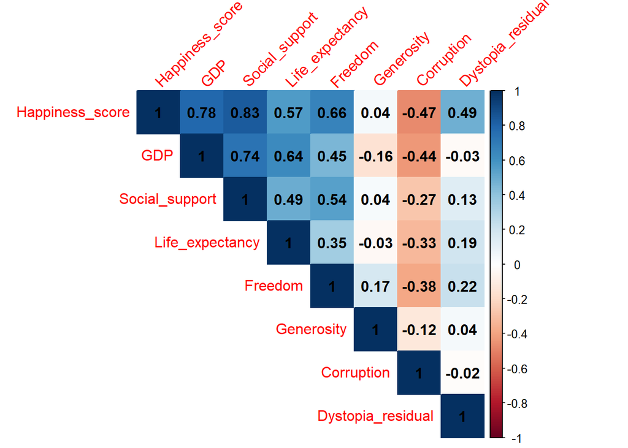

```r
# Coorelation graph
library(corrplot)

# Select the columns of interest from dataNumerical
selected_columns <- dataNumerical[, c("Happiness_score", "GDP", "Social_support", "Life_expectancy", "Freedom", "Generosity", "Corruption", "Dystopia_residual")]

# Compute the correlation matrix
correlation_matrix <- cor(selected_columns)

# Plot the correlation matrix
corrplot(correlation_matrix,
         method = "color",
         sig.level = 0.01,
         insig = "blank",
         addCoef.col = "black",
         tl.srt = 45,
         type = "upper"
)
```

# Highly coorelated variable

```r
library(lattice)
library(ggplot2)
library(caret)
#Finding highly correlated variables
highly_correlated <- findCorrelation(cor(dataNumerical), cutoff = 0.7)
cat("Highly correlated variables are:", colnames(dataNumerical)[highly_correlated])
```

```
## Highly correlated variables are: Happiness_score GDP
```

> Happiness_score and GDP is highly correlated with Happiness score.

# STEP 9 : CREATING TRAINING AND TEST DATASET

# Spliting the data into training and testing data

```r
data1 <- subset(data, select=c("Happiness_score", "GDP", "Social_support", "Life_expectancy", "Freedom", "Generosity", "Corruption", "Dystopia_residual","Region"))

i <- sample(2, size=nrow(data1), replace=TRUE, prob=c(0.8, 0.2))
dataTraining <- data1[i==1,]
dataTest <- data1[i==2,]

cat("Total observations in Training data set is ",nrow(dataTraining))
```

```
## Total observations in Training data set is  109
```

```r
cat("\nTotal observations in Testing data set is ",nrow(dataTest))
```

```
##
## Total observations in Testing data set is  28
```

# STEP 10 : CREATING LINEAR REGRESSION MODELS

# 1. Simple Linear Regression Model

# Constructing a simple linear regression model of Happiness Score by GDP to carry out regression on the data.

```r
Simple_Linear_Model <- lm(Happiness_score~GDP, data=dataTraining)
Simple_Linear_Model_Summary <- summary(Simple_Linear_Model)
Simple_Linear_Model_Summary
```

```
##
## Call:
## lm(formula = Happiness_score ~ GDP, data = dataTraining)
##
## Residuals:
##      Min       1Q   Median       3Q      Max
## -2.09964 -0.30955 -0.01047  0.34036  2.60867
##
## Coefficients:
##             Estimate Std. Error t value Pr(>|t|)
## (Intercept) -1.56925    0.45326  -3.462 0.000771 ***
## GDP          0.75476    0.04764  15.843  < 2e-16 ***
## ---
## Signif. codes:  0 '***' 0.001 '**' 0.01 '*' 0.05 '.' 0.1 ' ' 1
##
## Residual standard error: 0.6053 on 107 degrees of freedom
## Multiple R-squared:  0.7011, Adjusted R-squared:  0.6983
## F-statistic:   251 on 1 and 107 DF,  p-value: < 2.2e-16
```

> How strong is the relationship between the predictor and the response? p-value is close to zero, thus relationship is strong

> Is the relationship between the predictor and the response positive or negative? The coefficient is positive and hence there is a positive relationship

# Using Simple Linear Regression Model to predict Happiness Score in dataTest.

```r
y_Simple_Linear_Model_Pred <-predict(object = Simple_Linear_Model, newdata = dataTest)
summary(y_Simple_Linear_Model_Pred)
```

```
##    Min. 1st Qu.  Median    Mean 3rd Qu.    Max.
##   3.802   5.122   5.634   5.603   6.401   7.131
```

# Predicting Test Set Results for Simple Linear Regression Model

```r
Simple_Linear_Model_Pred_DF <- as.data.frame(cbind(Prediction = y_Simple_Linear_Model_Pred, Actual = dataTest$Happiness_score))

Simple_Linear_Model_Pred_DF
```

|  | Prediction | Actual |
| --- | --- | --- |
| 1 | 6.576161 | 7.804 |
| 2 | 6.644844 | 7.395 |
| 3 | 6.656920 | 7.097 |
| 4 | 7.130912 | 6.911 |
| 5 | 6.386715 | 6.455 |
| 6 | 6.064431 | 6.334 |
| 7 | 5.865173 | 6.330 |
| 8 | 4.935305 | 6.259 |
| 9 | 6.564084 | 6.173 |
| 10 | 6.443322 | 6.129 |

[output cut: 18 more lines]

# Finding RSS, R^2, MAE, MSE, RSE values for simple linear regression model.

```r
library(MLmetrics)
#MAE
Simple_Linear_Model_MAE <- MAE(y_pred = y_Simple_Linear_Model_Pred, y_true = dataTest$Happiness_score)

#MSE
Simple_Linear_Model_MSE <- MSE(y_pred = y_Simple_Linear_Model_Pred, y_true = dataTest$Happiness_score)

#RSS
Simple_Linear_Model_Residual <- resid(Simple_Linear_Model)
Simple_Linear_Model_RSS <- sum(Simple_Linear_Model_Residual^2)

#$R^2$
Simple_Linear_Model_RSquare <- Simple_Linear_Model_Summary$r.squared

#RSE
Simple_Linear_Model_RSE <- Simple_Linear_Model_Summary$sigma

cat("RSS For Simple Linear Regression Model is:",Simple_Linear_Model_RSS)
```

```
## RSS For Simple Linear Regression Model is: 39.20093
```

```r
cat("\nR Squared For Simple Linear Regression Model is:",Simple_Linear_Model_RSquare)
```

```
##
## R Squared For Simple Linear Regression Model is: 0.7011199
```

```r
cat("\nMAE For Simple Linear Regression Model is:",Simple_Linear_Model_MAE)
```

```
##
## MAE For Simple Linear Regression Model is: 0.7640046
```

```r
cat("\nMSE For Simple Linear Regression Model is:",Simple_Linear_Model_MSE)
```

```
##
## MSE For Simple Linear Regression Model is: 1.032532
```

```r
cat("\nRSE For Simple Linear Regression Model is:",Simple_Linear_Model_RSE)
```

```
##
## RSE For Simple Linear Regression Model is: 0.60528
```

> Mean Absolute Error is the mean of summation of absolute value of actual minus predicted response. Mean Square Error is the mean of summation of square of the actual minus predicted response value. Residual Sum of Square is the summation of square of the actual minus predicted response value. The minimum the above three value, the better the model.

> Residual Standard Error is a measure of lack of fit of the model to the data. If predicted value for one or more observations is far from actual value then RSE will be large indicating a model that does not fit the data well. What constitutes a good RSE is not well defined.

> R2 lies between zero and 1. Higher the value, the better. But the decision is practically made on the application.

# 2. Multiple Linear Regression Model

# Constructing a multiple linear regression model of Happiness Score by all features to carry out regression on the data.

```r
Multiple_Regression_Model <- lm(Happiness_score~. , data=dataTraining)
Multiple_Regression_Model_Summary <- summary(Multiple_Regression_Model)
Multiple_Regression_Model_Summary
```

```
##
## Call:
## lm(formula = Happiness_score ~ ., data = dataTraining)
##
## Residuals:
##       Min        1Q    Median        3Q       Max
## -0.208323 -0.065268  0.000663  0.053372  0.306589
##
## Coefficients:
##                                     Estimate Std. Error t value Pr(>|t|)
## (Intercept)                        -1.691431   0.206957  -8.173 1.47e-12 ***
## GDP                                 0.403582   0.018907  21.346  < 2e-16 ***
## Social_support                      2.930025   0.152821  19.173  < 2e-16 ***
## Life_expectancy                    -0.015959   0.001706  -9.356 4.72e-15 ***
## Freedom                             1.340896   0.138541   9.679 9.78e-16 ***
## Generosity                          0.480991   0.092389   5.206 1.15e-06 ***
## Corruption                         -0.781101   0.086009  -9.082 1.79e-14 ***
## Dystopia_residual                   0.933699   0.025928  36.011  < 2e-16 ***
## RegionEast Asia                     0.058536   0.054623   1.072   0.2867
## RegionLatin America and Caribbean   0.033855   0.043970   0.770   0.4433
## RegionMiddle East and North Africa  0.044239   0.044797   0.988   0.3259
## RegionNorth America and ANZ         0.053032   0.064102   0.827   0.4102
## RegionSouth Asia                   -0.131780   0.067873  -1.942   0.0552 .
## RegionSoutheast Asia               -0.048579   0.041667  -1.166   0.2466
## RegionSub-Saharan Africa           -0.251876   0.049361  -5.103 1.76e-06 ***
## RegionWestern Europe                0.121981   0.046784   2.607   0.0106 *
## ---
## Signif. codes:  0 '***' 0.001 '**' 0.01 '*' 0.05 '.' 0.1 ' ' 1
##
## Residual standard error: 0.1045 on 93 degrees of freedom
## Multiple R-squared:  0.9923, Adjusted R-squared:  0.991
## F-statistic: 794.7 on 15 and 93 DF,  p-value: < 2.2e-16
```

# Now we will again construct multiple linear regression without Region variable.

```r
Multiple_Regression_Model <- lm(Happiness_score~. -Region , data=dataTraining)
Multiple_Regression_Model_Summary <- summary(Multiple_Regression_Model)
Multiple_Regression_Model_Summary
```

```
##
## Call:
## lm(formula = Happiness_score ~ . - Region, data = dataTraining)
##
## Residuals:
##      Min       1Q   Median       3Q      Max
## -0.43250 -0.06742 -0.00111  0.06368  0.49077
##
## Coefficients:
##                    Estimate Std. Error t value Pr(>|t|)
## (Intercept)       -2.456168   0.169969 -14.451  < 2e-16 ***
## GDP                0.437786   0.019624  22.309  < 2e-16 ***
## Social_support     3.320915   0.152366  21.796  < 2e-16 ***
## Life_expectancy   -0.013891   0.001963  -7.077 1.99e-10 ***
## Freedom            1.355789   0.149056   9.096 8.78e-15 ***
## Generosity         0.309044   0.097660   3.164  0.00205 **
## Corruption        -0.831493   0.084845  -9.800 2.47e-16 ***
## Dystopia_residual  0.925697   0.027819  33.276  < 2e-16 ***
## ---
## Signif. codes:  0 '***' 0.001 '**' 0.01 '*' 0.05 '.' 0.1 ' ' 1
##
## Residual standard error: 0.1269 on 101 degrees of freedom
## Multiple R-squared:  0.9876, Adjusted R-squared:  0.9867
## F-statistic:  1149 on 7 and 101 DF,  p-value: < 2.2e-16
```

# Using Multiple Linear Regression Model to predict Happiness Score in dataTest.

```r
y_Multiple_Regression_Model_Pred <-predict(object = Multiple_Regression_Model, newdata = dataTest)
summary(y_Multiple_Regression_Model_Pred)
```

```
##    Min. 1st Qu.  Median    Mean 3rd Qu.    Max.
##   2.291   4.932   5.805   5.508   6.237   7.831
```

# Predicting Test Set Results for Multiple Linear Regression Model

```r
Multiple_Regression_Model_Pred_DF <- as.data.frame(cbind(Prediction = y_Multiple_Regression_Model_Pred, Actual = dataTest$Happiness_score))

Multiple_Regression_Model_Pred_DF
```

|  | Prediction | Actual |
| --- | --- | --- |
| 1 | 7.831144 | 7.804 |
| 2 | 7.354253 | 7.395 |
| 3 | 7.019512 | 7.097 |
| 4 | 6.951082 | 6.911 |
| 5 | 6.542161 | 6.455 |
| 6 | 6.221817 | 6.334 |
| 7 | 6.316395 | 6.330 |
| 8 | 6.179383 | 6.259 |
| 9 | 6.284205 | 6.173 |
| 10 | 6.005912 | 6.129 |

[output cut: 18 more lines]

# Finding RSS, R^2, MAE and MSE values for Multiple linear regression model.

```r
library(MLmetrics)

#MAE
Multiple_Regression_Model_MAE <- MAE(y_pred = y_Multiple_Regression_Model_Pred, y_true = dataTest$Happiness_score)

#MSE
Multiple_Regression_Model_MSE <- MSE(y_pred = y_Multiple_Regression_Model_Pred, y_true = dataTest$Happiness_score)

#RSS
Multiple_Regression_Model_Residual <- resid(Multiple_Regression_Model)
Multiple_Regression_Model_RSS <- sum(Multiple_Regression_Model_Residual^2)

#$R^2$
Multiple_Regression_Model_RSquare <- Multiple_Regression_Model_Summary$r.squared

#RSE
Multiple_Regression_Model_RSE <- Multiple_Regression_Model_Summary$sigma


cat("RSS For Multiple Linear Regression Model is:",Multiple_Regression_Model_RSS)
```

```
## RSS For Multiple Linear Regression Model is: 1.626375
```

```r
cat("\nR Squared For Multiple Linear Regression Model is:",Multiple_Regression_Model_RSquare)
```

```
##
## R Squared For Multiple Linear Regression Model is: 0.9876
```

```r
cat("\nMAE For Multiple Linear Regression Model is:",Multiple_Regression_Model_MAE)
```

```
##
## MAE For Multiple Linear Regression Model is: 0.1234451
```

```r
cat("\nMSE For Multiple Linear Regression Model is:",Multiple_Regression_Model_MSE)
```

```
##
## MSE For Multiple Linear Regression Model is: 0.02953841
```

```r
cat("\nRSE For Multiple Linear Regression Model is:",Multiple_Regression_Model_RSE)
```

```
##
## RSE For Multiple Linear Regression Model is: 0.1268965
```

> The MSE, MAE, RSE are too small. Suggesting a good model or an overfit. Since they were calculated on testing data, we do not think it is overfitting and conclude it is a good model.

# 3. Forward Stepwise Subset Selection Linear Regression Model

> Begins with Null Model Fit p simple linear regressions and add to the null model the variable that results in the lowest RSS. Add to that model the variable that results in the lowest RSS amongst all two-variable models. Continue until some stopping rule is satisfied, for example when all remaining variables have a p-value above some threshold.

```r
library(MASS)
# Create a null model
forward_intercept_only <- lm(Happiness_score ~ 1, data=dataTraining)
# Create a full model
forward_all <- lm(Happiness_score~., data=dataTraining)
# perform forward step-wise regression
Forward_Regression_Model <- stepAIC (forward_intercept_only, direction='forward',scope = formula(forward_all))
```

```
## Start:  AIC=22.17
## Happiness_score ~ 1
##
##                     Df Sum of Sq     RSS      AIC
## + Social_support     1    92.799  38.361 -109.830
## + GDP                1    91.958  39.201 -107.469
## + Region             8    91.458  39.701  -92.086
## + Freedom            1    51.780  79.379  -30.565
## + Life_expectancy    1    42.270  88.889  -18.231
## + Dystopia_residual  1    25.474 105.686    0.634
## + Corruption         1    23.339 107.821    2.814
## <none>                           131.159   22.172
## + Generosity         1     0.000 131.159   24.172
##
## Step:  AIC=-109.83
## Happiness_score ~ Social_support
##
##                     Df Sum of Sq    RSS     AIC
## + Dystopia_residual  1   16.1532 22.208 -167.41
## + GDP                1   12.8556 25.505 -152.32
## + Region             8   11.7861 26.575 -133.84
## + Corruption         1    8.0937 30.267 -133.66
## + Freedom            1    8.0480 30.313 -133.50
## + Life_expectancy    1    4.7275 33.633 -122.17
## <none>                           38.361 -109.83
## + Generosity         1    0.0956 38.265 -108.10
##
## Step:  AIC=-167.41
## Happiness_score ~ Social_support + Dystopia_residual
##
##                   Df Sum of Sq     RSS     AIC
## + GDP              1   15.2224  6.9851 -291.48
## + Corruption       1    9.2724 12.9351 -224.32
## + Region           8    9.0318 13.1758 -208.31
## + Freedom          1    6.1124 16.0952 -200.50
## + Life_expectancy  1    1.3629 20.8447 -172.31
## <none>                         22.2076 -167.41
## + Generosity       1    0.0082 22.1994 -165.45
##
## Step:  AIC=-291.48
```

[output cut: 36 more lines]

```
## + Region      8   0.47635 1.3113 -451.82
## + Generosity  1   0.16125 1.6264 -442.34
## <none>                    1.7876 -434.04
##
## Step:  AIC=-451.82
## Happiness_score ~ Social_support + Dystopia_residual + GDP +
##     Corruption + Freedom + Life_expectancy + Region
##
##              Df Sum of Sq    RSS     AIC
## + Generosity  1   0.29592 1.0154 -477.70
## <none>                    1.3113 -451.82
##
## Step:  AIC=-477.7
## Happiness_score ~ Social_support + Dystopia_residual + GDP +
##     Corruption + Freedom + Life_expectancy + Region + Generosity
```

# Viewing Results of Forward Stepwise Subset Selection Linear Regression Model

```r
# view results of forward stepwise regression
Forward_Regression_Model$anova
```

| Step | Df | Deviance | Resid. Df | Resid. Dev | AIC |
| --- | --- | --- | --- | --- | --- |
|  | NA | NA | 108 | 131.159401 | 22.17214 |
| + Social_support | 1 | 92.7985964 | 107 | 38.360805 | -109.82997 |
| + Dystopia_residual | 1 | 16.1532185 | 106 | 22.207586 | -167.40962 |
| + GDP | 1 | 15.2224433 | 105 | 6.985143 | -291.48430 |
| + Corruption | 1 | 2.8113170 | 104 | 4.173826 | -345.61411 |
| + Freedom | 1 | 1.6470146 | 103 | 2.526811 | -398.31848 |
| + Life_expectancy | 1 | 0.7391839 | 102 | 1.787628 | -434.03998 |
| + Region | 8 | 0.4763467 | 94 | 1.311281 | -451.81744 |
| + Generosity | 1 | 0.2959185 | 93 | 1.015362 | -477.69515 |

# Viewing summary for Forward Stepwise Subset Selection Linear Regression Model

```r
# view final model
Forward_Regression_Model_Summary <- summary(Forward_Regression_Model)
Forward_Regression_Model_Summary
```

```
##
## Call:
## lm(formula = Happiness_score ~ Social_support + Dystopia_residual +
##     GDP + Corruption + Freedom + Life_expectancy + Region + Generosity,
##     data = dataTraining)
##
## Residuals:
##       Min        1Q    Median        3Q       Max
## -0.208323 -0.065268  0.000663  0.053372  0.306589
##
## Coefficients:
##                                     Estimate Std. Error t value Pr(>|t|)
## (Intercept)                        -1.691431   0.206957  -8.173 1.47e-12 ***
## Social_support                      2.930025   0.152821  19.173  < 2e-16 ***
## Dystopia_residual                   0.933699   0.025928  36.011  < 2e-16 ***
## GDP                                 0.403582   0.018907  21.346  < 2e-16 ***
## Corruption                         -0.781101   0.086009  -9.082 1.79e-14 ***
## Freedom                             1.340896   0.138541   9.679 9.78e-16 ***
## Life_expectancy                    -0.015959   0.001706  -9.356 4.72e-15 ***
## RegionEast Asia                     0.058536   0.054623   1.072   0.2867
## RegionLatin America and Caribbean   0.033855   0.043970   0.770   0.4433
## RegionMiddle East and North Africa  0.044239   0.044797   0.988   0.3259
## RegionNorth America and ANZ         0.053032   0.064102   0.827   0.4102
## RegionSouth Asia                   -0.131780   0.067873  -1.942   0.0552 .
## RegionSoutheast Asia               -0.048579   0.041667  -1.166   0.2466
## RegionSub-Saharan Africa           -0.251876   0.049361  -5.103 1.76e-06 ***
## RegionWestern Europe                0.121981   0.046784   2.607   0.0106 *
## Generosity                          0.480991   0.092389   5.206 1.15e-06 ***
## ---
## Signif. codes:  0 '***' 0.001 '**' 0.01 '*' 0.05 '.' 0.1 ' ' 1
##
## Residual standard error: 0.1045 on 93 degrees of freedom
## Multiple R-squared:  0.9923, Adjusted R-squared:  0.991
## F-statistic: 794.7 on 15 and 93 DF,  p-value: < 2.2e-16
```

# Using Forward Stepwise Subset Selection Linear Regression Model to predict Happiness Score in dataTest.

```r
y_Forward_Regression_Model_Pred <-predict(object = Forward_Regression_Model, newdata = dataTest)
summary(y_Forward_Regression_Model_Pred)
```

```
##    Min. 1st Qu.  Median    Mean 3rd Qu.    Max.
##   2.444   4.881   5.867   5.511   6.248   7.833
```

# Predicting Test Set Results for Forward Stepwise Subset Selection Linear Regression Model

```r
Forward_Regression_Model_Pred_DF <- as.data.frame(cbind(Prediction = y_Forward_Regression_Model_Pred, Actual = dataTest$Happiness_score))

Forward_Regression_Model_Pred_DF
```

|  | Prediction | Actual |
| --- | --- | --- |
| 1 | 7.833347 | 7.804 |
| 2 | 7.392160 | 7.395 |
| 3 | 7.086062 | 7.097 |
| 4 | 6.975557 | 6.911 |
| 5 | 6.455901 | 6.455 |
| 6 | 6.225721 | 6.334 |
| 7 | 6.356656 | 6.330 |
| 8 | 6.221811 | 6.259 |
| 9 | 6.314152 | 6.173 |
| 10 | 5.954597 | 6.129 |

[output cut: 18 more lines]

# Finding RSS, R^2, MAE and MSE values for Forward Stepwise Subset Selection Linear Regression Model

```r
library(MLmetrics)

#MAE
Forward_Regression_Model_MAE <- MAE(y_pred = y_Forward_Regression_Model_Pred, y_true = dataTest$Happiness_score)

#MSE
Forward_Regression_Model_MSE <- MSE(y_pred = y_Forward_Regression_Model_Pred, y_true = dataTest$Happiness_score)

#RSS
Forward_Regression_Model_Residual <- resid(Forward_Regression_Model)
Forward_Regression_Model_RSS <- sum(Forward_Regression_Model_Residual^2)

#$R^2$
Forward_Regression_Model_RSquare <- Forward_Regression_Model_Summary$r.squared

#RSE
Forward_Regression_Model_RSE <- Forward_Regression_Model_Summary$sigma

cat("RSS For Forward Stepwise Subset Selection Linear Regression Model is:",Forward_Regression_Model_RSS)
```

```
## RSS For Forward Stepwise Subset Selection Linear Regression Model is: 1.015362
```

```r
cat("\nR Squared For Forward Stepwise Subset Selection Linear Regression Model is:",Forward_Regression_Model_RSquare)
```

```
##
## R Squared For Forward Stepwise Subset Selection Linear Regression Model is: 0.9922586
```

```r
cat("\nMAE For Forward Stepwise Subset Selection Linear Regression Model is:",Forward_Regression_Model_MAE)
```

```
##
## MAE For Forward Stepwise Subset Selection Linear Regression Model is: 0.1007783
```

```r
cat("\nMSE For Forward Stepwise Subset Selection Linear Regression Model is:",Forward_Regression_Model_MSE)
```

```
##
## MSE For Forward Stepwise Subset Selection Linear Regression Model is: 0.01818754
```

```r
cat("\nRSE For Forward Stepwise Subset Selection Linear Regression Model is:",Forward_Regression_Model_RSE)
```

```
##
## RSE For Forward Stepwise Subset Selection Linear Regression Model is: 0.1044886
```

# 4. Backward Stepwise Subset Selection Linear Regression Model

> Start with all variables in the model. Remove the variable with the largest p-value — that is, the variable that is the least statistically significant. The new (p−1) variable model is fit, and the variable with the largest p-value is removed. Continue until a stopping rule is reached.

```r
# Create a full model
backward_all <- lm(Happiness_score~., data=dataTraining)
# perform Backward step-wise regression
Backward_Regression_Model <- stepAIC (backward_all, direction='backward')
```

```
## Start:  AIC=-477.7
## Happiness_score ~ GDP + Social_support + Life_expectancy + Freedom +
##     Generosity + Corruption + Dystopia_residual + Region
##
##                     Df Sum of Sq     RSS     AIC
## <none>                            1.0154 -477.70
## - Generosity         1    0.2959  1.3113 -451.82
## - Region             8    0.6110  1.6264 -442.34
## - Corruption         1    0.9005  1.9158 -410.49
## - Life_expectancy    1    0.9557  1.9710 -407.39
## - Freedom            1    1.0228  2.0381 -403.75
## - Social_support     1    4.0134  5.0288 -305.30
## - GDP                1    4.9746  5.9900 -286.24
## - Dystopia_residual  1   14.1584 15.1737 -184.92
```

# Viewing Results of Backward Stepwise Subset Selection Linear Regression Model

```r
# view results of backward stepwise regression
Backward_Regression_Model$anova
```

| Step | Df | Deviance | Resid. Df | Resid. Dev | AIC |
| --- | --- | --- | --- | --- | --- |
|  | NA | NA | 93 | 1.015362 | -477.6952 |

# Viewing summary for Backward Stepwise Subset Selection Linear Regression Model

```r
# view final model
Backward_Regression_Model_Summary <- summary(Backward_Regression_Model)
Backward_Regression_Model_Summary
```

```
##
## Call:
## lm(formula = Happiness_score ~ GDP + Social_support + Life_expectancy +
##     Freedom + Generosity + Corruption + Dystopia_residual + Region,
##     data = dataTraining)
##
## Residuals:
##       Min        1Q    Median        3Q       Max
## -0.208323 -0.065268  0.000663  0.053372  0.306589
##
## Coefficients:
##                                     Estimate Std. Error t value Pr(>|t|)
## (Intercept)                        -1.691431   0.206957  -8.173 1.47e-12 ***
## GDP                                 0.403582   0.018907  21.346  < 2e-16 ***
## Social_support                      2.930025   0.152821  19.173  < 2e-16 ***
## Life_expectancy                    -0.015959   0.001706  -9.356 4.72e-15 ***
## Freedom                             1.340896   0.138541   9.679 9.78e-16 ***
## Generosity                          0.480991   0.092389   5.206 1.15e-06 ***
## Corruption                         -0.781101   0.086009  -9.082 1.79e-14 ***
## Dystopia_residual                   0.933699   0.025928  36.011  < 2e-16 ***
## RegionEast Asia                     0.058536   0.054623   1.072   0.2867
## RegionLatin America and Caribbean   0.033855   0.043970   0.770   0.4433
## RegionMiddle East and North Africa  0.044239   0.044797   0.988   0.3259
## RegionNorth America and ANZ         0.053032   0.064102   0.827   0.4102
## RegionSouth Asia                   -0.131780   0.067873  -1.942   0.0552 .
## RegionSoutheast Asia               -0.048579   0.041667  -1.166   0.2466
## RegionSub-Saharan Africa           -0.251876   0.049361  -5.103 1.76e-06 ***
## RegionWestern Europe                0.121981   0.046784   2.607   0.0106 *
## ---
## Signif. codes:  0 '***' 0.001 '**' 0.01 '*' 0.05 '.' 0.1 ' ' 1
##
## Residual standard error: 0.1045 on 93 degrees of freedom
## Multiple R-squared:  0.9923, Adjusted R-squared:  0.991
## F-statistic: 794.7 on 15 and 93 DF,  p-value: < 2.2e-16
```

# Using Backward Stepwise Subset Selection Linear Regression Model to predict Happiness Score in dataTest.

```r
y_Backward_Regression_Model_Pred <-predict(object = Backward_Regression_Model, newdata = dataTest)
summary(y_Backward_Regression_Model_Pred)
```

```
##    Min. 1st Qu.  Median    Mean 3rd Qu.    Max.
##   2.444   4.881   5.867   5.511   6.248   7.833
```

# Using Backward Stepwise Subset Selection Linear Regression Model to predict Confidence Interval on Happiness Score in dataTest.

```r
y_Backward_Regression_Model_Pred_conf <-predict(object = Backward_Regression_Model, newdata = dataTest, interval="confidence")
summary(y_Backward_Regression_Model_Pred_conf)
```

```
##       fit             lwr             upr
##  Min.   :2.444   Min.   :2.304   Min.   :2.585
##  1st Qu.:4.881   1st Qu.:4.798   1st Qu.:4.965
##  Median :5.867   Median :5.783   Median :5.951
##  Mean   :5.511   Mean   :5.425   Mean   :5.597
##  3rd Qu.:6.248   3rd Qu.:6.173   3rd Qu.:6.336
##  Max.   :7.833   Max.   :7.742   Max.   :7.924
```

# Predicting Test Set Results for Backward Stepwise Subset Selection Linear Regression Model

```r
Backward_Regression_Model_Pred_DF <- as.data.frame(cbind(Prediction = y_Backward_Regression_Model_Pred, Actual = dataTest$Happiness_score))

Backward_Regression_Model_Pred_DF
```

|  | Prediction | Actual |
| --- | --- | --- |
| 1 | 7.833347 | 7.804 |
| 2 | 7.392160 | 7.395 |
| 3 | 7.086062 | 7.097 |
| 4 | 6.975557 | 6.911 |
| 5 | 6.455901 | 6.455 |
| 6 | 6.225721 | 6.334 |
| 7 | 6.356656 | 6.330 |
| 8 | 6.221811 | 6.259 |
| 9 | 6.314152 | 6.173 |
| 10 | 5.954597 | 6.129 |

[output cut: 18 more lines]

# Finding RSS, R^2, MAE and MSE values for Backward Stepwise Subset Selection Linear Regression Model

```r
library(MLmetrics)

#MAE
Backward_Regression_Model_MAE <- MAE(y_pred = y_Backward_Regression_Model_Pred, y_true = dataTest$Happiness_score)

#MSE
Backward_Regression_Model_MSE <- MSE(y_pred = y_Backward_Regression_Model_Pred, y_true = dataTest$Happiness_score)

#RSS
Backward_Regression_Model_Residual <- resid(Backward_Regression_Model)
Backward_Regression_Model_RSS <- sum(Backward_Regression_Model_Residual^2)

#$R^2$
Backward_Regression_Model_RSquare <- Backward_Regression_Model_Summary$r.squared

#RSE
Backward_Regression_Model_RSE <- Backward_Regression_Model_Summary$sigma


cat("RSS For Backward Stepwise Subset Selection Linear Regression Model is:",Backward_Regression_Model_RSS)
```

```
## RSS For Backward Stepwise Subset Selection Linear Regression Model is: 1.015362
```

```r
cat("\nR Squared For Backward Stepwise Subset Selection Linear Regression Model is:",Backward_Regression_Model_RSquare)
```

```
##
## R Squared For Backward Stepwise Subset Selection Linear Regression Model is: 0.9922586
```

```r
cat("\nMAE For Backward Stepwise Subset Selection Linear Regression Model is:",Backward_Regression_Model_MAE)
```

```
##
## MAE For Backward Stepwise Subset Selection Linear Regression Model is: 0.1007783
```

```r
cat("\nMSE For Backward Stepwise Subset Selection Linear Regression Model is:",Backward_Regression_Model_MSE)
```

```
##
## MSE For Backward Stepwise Subset Selection Linear Regression Model is: 0.01818754
```

```r
cat("\nRSE For Backward Stepwise Subset Selection Linear Regression Model is:",Backward_Regression_Model_RSE)
```

```
##
## RSE For Backward Stepwise Subset Selection Linear Regression Model is: 0.1044886
```

# STEP 11 : MODEL ASSESSMENT

# 1. Simple Linear Regression Model

```r
cat("RSS For Simple Linear Regression Model is:",Simple_Linear_Model_RSS)
```

```
## RSS For Simple Linear Regression Model is: 39.20093
```

```r
cat("\nR Squared For Simple Linear Regression Model is:",Simple_Linear_Model_RSquare)
```

```
##
## R Squared For Simple Linear Regression Model is: 0.7011199
```

```r
cat("\nMAE For Simple Linear Regression Model is:",Simple_Linear_Model_MAE)
```

```
##
## MAE For Simple Linear Regression Model is: 0.7640046
```

```r
cat("\nMSE For Simple Linear Regression Model is:",Simple_Linear_Model_MSE)
```

```
##
## MSE For Simple Linear Regression Model is: 1.032532
```

```r
cat("\nRSE For Simple Linear Regression Model is:",Simple_Linear_Model_RSE)
```

```
##
## RSE For Simple Linear Regression Model is: 0.60528
```

# 2. Multiple Linear Regression Model

```r
cat("RSS For Multiple Linear Regression Model is:",Multiple_Regression_Model_RSS)
```

```
## RSS For Multiple Linear Regression Model is: 1.626375
```

```r
cat("\nR Squared For Multiple Linear Regression Model is:",Multiple_Regression_Model_RSquare)
```

```
##
## R Squared For Multiple Linear Regression Model is: 0.9876
```

```r
cat("\nMAE For Multiple Linear Regression Model is:",Multiple_Regression_Model_MAE)
```

```
##
## MAE For Multiple Linear Regression Model is: 0.1234451
```

```r
cat("\nMSE For Multiple Linear Regression Model is:",Multiple_Regression_Model_MSE)
```

```
##
## MSE For Multiple Linear Regression Model is: 0.02953841
```

```r
cat("\nRSE For Multiple Linear Regression Model is:",Multiple_Regression_Model_RSE)
```

```
##
## RSE For Multiple Linear Regression Model is: 0.1268965
```

# 3. Forward Stepwise subset selection Linear Regression Model

```r
cat("RSS For Forward Stepwise Subset Selection Linear Regression Model is:",Forward_Regression_Model_RSS)
```

```
## RSS For Forward Stepwise Subset Selection Linear Regression Model is: 1.015362
```

```r
cat("\nR Squared For Forward Stepwise Subset Selection Linear Regression Model is:",Forward_Regression_Model_RSquare)
```

```
##
## R Squared For Forward Stepwise Subset Selection Linear Regression Model is: 0.9922586
```

```r
cat("\nMAE For Forward Stepwise Subset Selection Linear Regression Model is:",Forward_Regression_Model_MAE)
```

```
##
## MAE For Forward Stepwise Subset Selection Linear Regression Model is: 0.1007783
```

```r
cat("\nMSE For Forward Stepwise Subset Selection Linear Regression Model is:",Forward_Regression_Model_MSE)
```

```
##
## MSE For Forward Stepwise Subset Selection Linear Regression Model is: 0.01818754
```

```r
cat("\nRSE For Forward Stepwise Subset Selection Linear Regression Model is:",Forward_Regression_Model_RSE)
```

```
##
## RSE For Forward Stepwise Subset Selection Linear Regression Model is: 0.1044886
```

# 4. Backward Stepwise subset selection Linear Regression Model

```r
cat("RSS For Backward Stepwise Subset Selection Linear Regression Model is:",Backward_Regression_Model_RSS)
```

```
## RSS For Backward Stepwise Subset Selection Linear Regression Model is: 1.015362
```

```r
cat("\nR Squared For Backward Stepwise Subset Selection Linear Regression Model is:",Backward_Regression_Model_RSquare)
```

```
##
## R Squared For Backward Stepwise Subset Selection Linear Regression Model is: 0.9922586
```

```r
cat("\nMAE For Backward Stepwise Subset Selection Linear Regression Model is:",Backward_Regression_Model_MAE)
```

```
##
## MAE For Backward Stepwise Subset Selection Linear Regression Model is: 0.1007783
```

```r
cat("\nMSE For Backward Stepwise Subset Selection Linear Regression Model is:",Backward_Regression_Model_MSE)
```

```
##
## MSE For Backward Stepwise Subset Selection Linear Regression Model is: 0.01818754
```

```r
cat("\nRSE For Backward Stepwise Subset Selection Linear Regression Model is:",Backward_Regression_Model_RSE)
```

```
##
## RSE For Backward Stepwise Subset Selection Linear Regression Model is: 0.1044886
```

> The Simple Linear Regression model uses only one predictor variable, and it appears to have the lowest performance compared to the other models, with a higher RSS, lower R-squared, higher MAE, and higher MSE, higher RSE. This model is useful when we want to study the relationship between two variables and see how a change in one variable affects the other.

> The Multiple Linear Regression model uses multiple predictor variables, and it has a lower RSS, higher R-squared, lower MAE, lower MSE and lower RSE than the Simple Linear Regression model. This model is helpful when we want to study the relationship between a response variable and multiple predictor variables and see how these predictors affect the response variable.